# Motor vehicle ownership in DC

pete rodrigue

2026-02-18

In January 2026, there were 118,907 vehicles registered with the DC DMV at 89,871 residential addresses, according to data provided in a recent FOIA request.

Keep in mind that this does not include any vehicles that are owned by DC residents, but registered in another state. This also doesn’t include vehicles registered at non-residential addresses, like rental cars, university vehicles, or federally-owned vehicles.

The DC DMV website says there are [310,000](https://dmv.dc.gov/page/about-dc-dmv) total vehicles registered in DC.

According to a 2023 U.S. DoT survey, there are [344,088](https://www.fhwa.dot.gov/policyinformation/statistics/2023/mv1.cfm) total motor vehicles registered in DC, of which [315,319](https://www.fhwa.dot.gov/policyinformation/statistics/2023/mv1.cfm) are privately owned (i.e. not owned by a government agency), which roughly aligns with the DMV website’s 310k figure.

If we add up the number of 7.5’x21’ parking spaces required for these 315,319 vehicles, we get a total area of 1.79 square miles (158 sqft * 315,319 vehicles * 3.58701e-8 sqmi/sqft). If you parked all of these vehicles bumper to bumper, they would cover Capitol Hill.

All 344,088 vehicles would cover closer to 2 square miles.

According to the 2020-2024 American Community Survey, [36%](https://data.census.gov/table/ACSDT5Y2024.B08201?t=Transportation&g=040XX00US11&y=2024) of DC households do not have a motor vehicle.

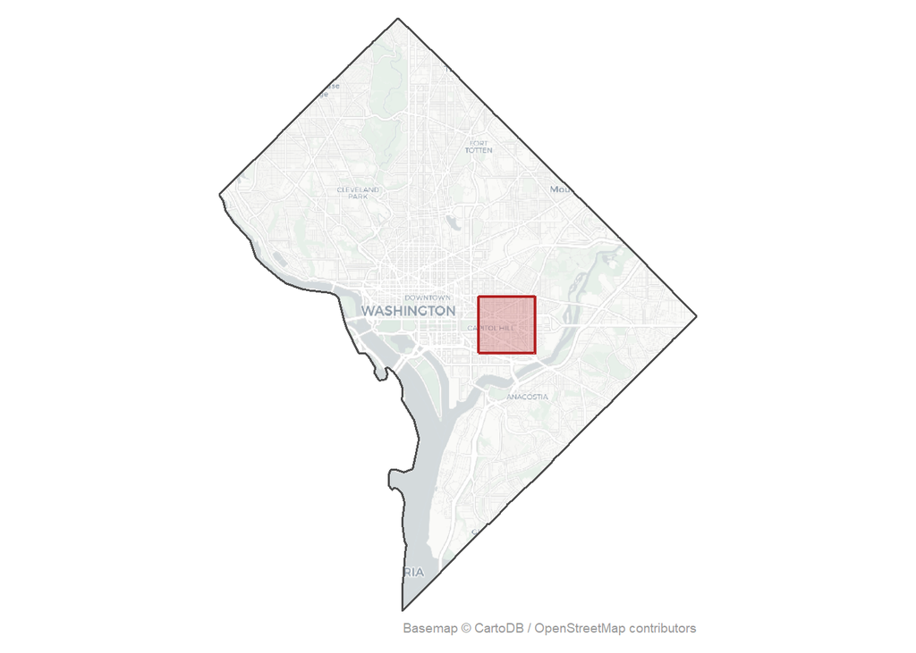

This is a massive underestimate of the amount of space actually taken up by parking, however. To get a rough, likely low-ball estimate of the amount of parking in DC, you can add up the following:

- the area of DC’s parking lots (5.14 sqmi)
- the area of DC’s ~150,000 RPP (0.85 sqmi), ~20,000 metered parking spots (0.11 sqmi), and ~230,000 “other” street spaces (1.3 sqmi)
- the area of DC’s single-family home parking spaces, assuming one parking space per single-family house (0.67 sqmi)

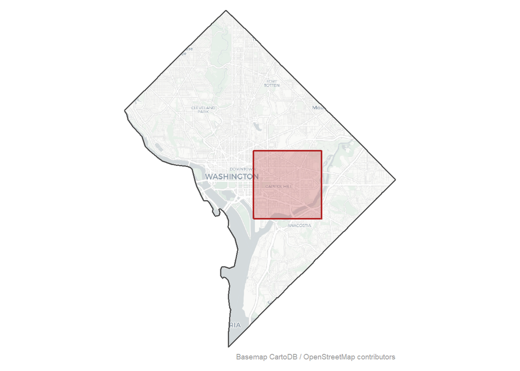

This covers over 8 square miles. This is still an underestimate. It doesn’t include underground parking, for example, or account for the fact that many single family homes have 2 parking spaces.

This write up will analyze the distribution of vehicle ownership in the data set DMV provided.

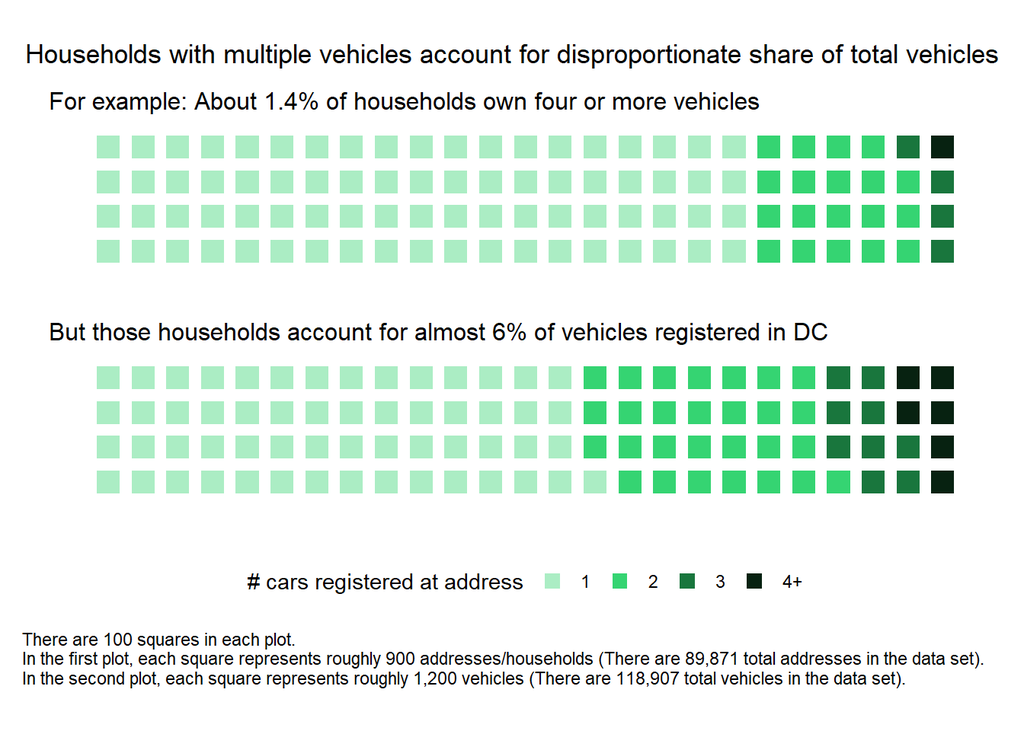

According to this FOIA’d data, here is the number of vehicles registered in each ANC Single Member District (SMD):

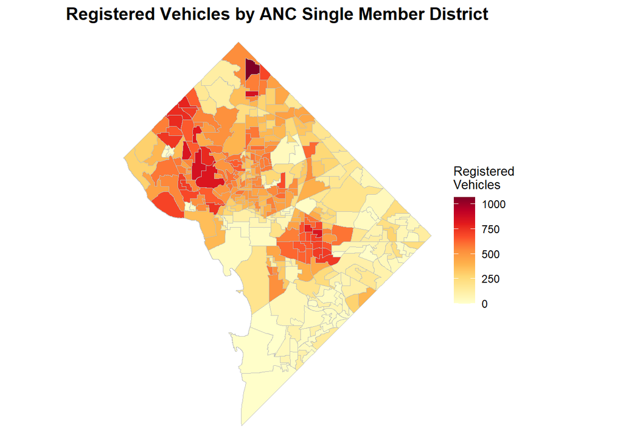

Here is the number of vehicles registered as a percentage of the number of households in the tract in 2020.

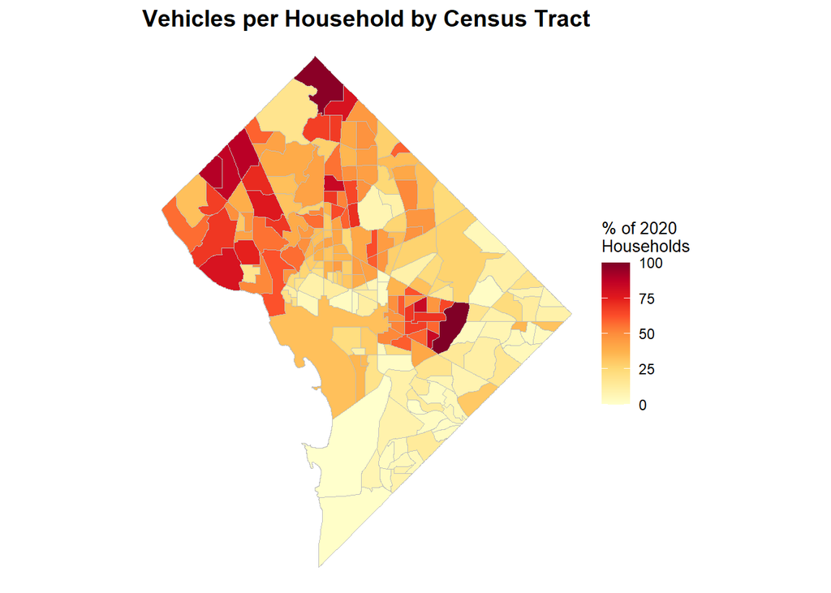

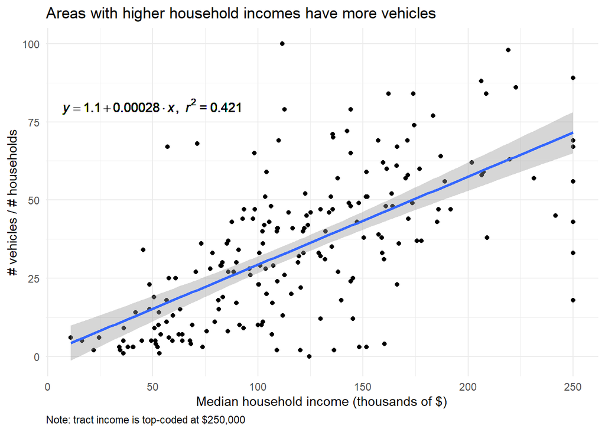

## Update May 11 2026!

The chart above appeared in the original Greater Greater Washington piece, but it was confusing. I took the total number of vehicles in each census tract and divided by the number of households in that census tract, then multiplied that by 100. So say we had a census tract with 100 households. If the y-axis value for that census tract was “50” that could mean that there were 50 households in that tract with 1 vehicle, or 1 household with 50 vehicles. I also top-coded this variable at 100, which made it look even more like a percentage (rather than a ratio) which was additionally confusing. (There were some census tracts in which there were, for example, 110 vehicles and 100 households, so the y-axis value was 110).

Below, I redo this so it’s clearer. I take the number of households that own at least one vehicle in the DMV data, and divide by the total number of households in the Census data. That gives you a rough estimate of the share of vehicle-owning households by tract (and by extension, the share of vehicle-free households). Note that this is a significant underestimate of the share of vehicle-owning households. We know for a fact (from the American Community Survey) that there are Census tracts in DC in which virtually all households have at least one vehicle. See here for example: https://onemap.cdc.gov/Portal/home/webmap/viewer.html?useExisting=1&layers=f82e556f2fca4df79aabaf6f15ed6830

We get this underestimate because the DMV data has some limitations. The data only includes residential registrations. It doesn’t include people who live in DC but have a car registered out of state. It doesn’t include people with fake tags, etc.

But the direction of the association (higher-income tracts have more vehicle ownership) is still almost certainly correct, despite these limitations. This is a strong association in the Consumer Expenditure Survey, for example: https://www.bts.gov/data-spotlight/transportation-cost-burden-falls-significantly-second-lowest-no-other-income-group

And lot of economic research finds that motor vehicles are “normal goods,” meaning that demand for the item rises as income rises:

- https://lindseyresearch.com/wp-content/uploads/2021/12/NHTSA-2021-0053-1575-Exhibit-41-McCarthy-1996.pdf
- https://media.rff.org/documents/WP_23-33.pdf
- https://www.sciencedirect.com/science/article/pii/S0965856400000185

Anyway, here’s the updated chart! Thanks to Leah Brooks at George Washington University for flagging this.

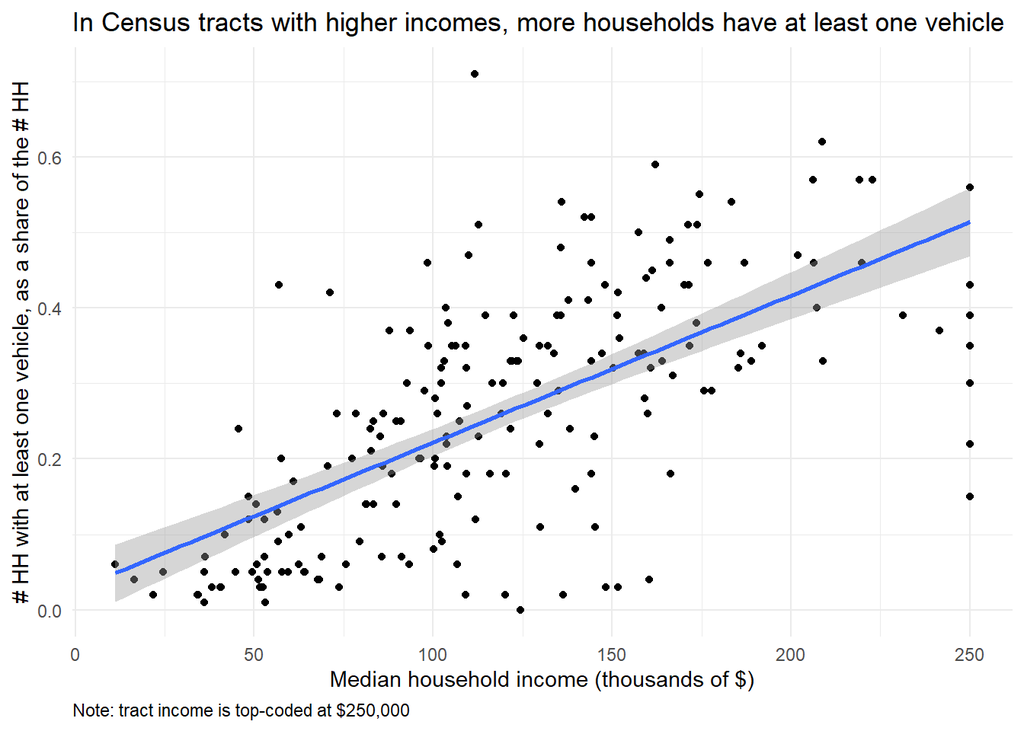

There are 43,919 registered vehicles within 800 meters of a metro station in DC according to this data set. That is 37% of the total number of vehicles.

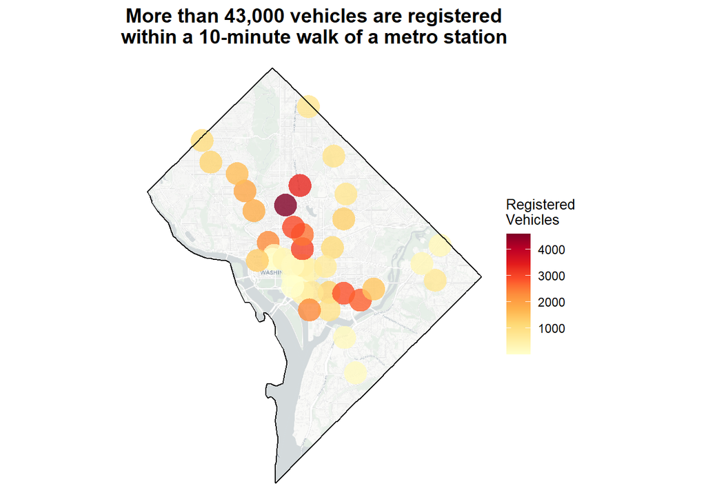

The map and table below shows the data at a granular level.

[interactive chart not shown]

|  | Address | Count of Vehicles |
| --- | --- | --- |
| 1 | 907 6TH ST SW 611C APT,WASHINGTON,DC,20024 | 22 |
| 2 | 522 KENYON ST NW,WASHINGTON,DC,20010 | 12 |
| 3 | 1300 SPRING RD NW,WASHINGTON,DC,20010 | 11 |
| 4 | 1347 RANDOLPH ST NW,WASHINGTON,DC,20011 | 10 |
| 5 | 50 TUCKERMAN ST NW,WASHINGTON,DC,20011 | 10 |
| 6 | 21 T ST NW,WASHINGTON,DC,20001 | 10 |
| 7 | 1300 36TH ST NW,WASHINGTON,DC,20007 | 10 |
| 8 | 1141 5TH ST NE,WASHINGTON,DC,20002 | 10 |
| 9 | 3616 FULTON ST NW,WASHINGTON,DC,20007 | 10 |
| 10 | 6609 GEORGIA AVE NW,WASHINGTON,DC,20012 | 10 |

[output cut: 89861 more lines]